# Week 8: Time Series Regression Analysis, Part 2

Xuan Pham

10/7/2019

## On Autocorrelation

Last week, we examined time series regression models where the residuals are not correlated (i.e white noise). What happens if the residuals are correlated?

```r
library(fpp2)
```

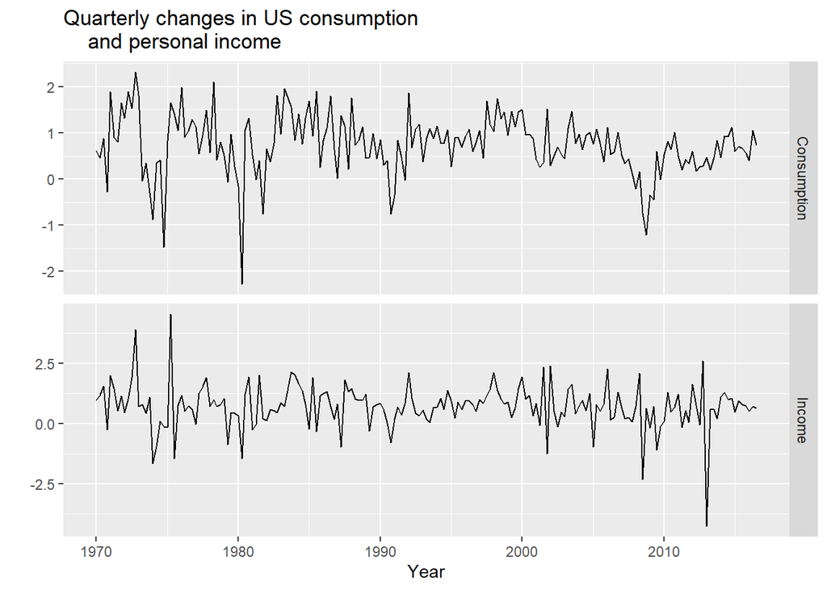

```r
autoplot(uschange[,1:2], facets=TRUE) +
  xlab("Year") + ylab("") +
  ggtitle("Quarterly changes in US consumption
    and personal income")
```

```r
cons_series <- uschange[,1:2]


ts.reg1 <- tslm(Consumption ~ Income, data= cons_series)
summary(ts.reg1)
```

```
##
## Call:
## tslm(formula = Consumption ~ Income, data = cons_series)
##
## Residuals:
##      Min       1Q   Median       3Q      Max
## -2.40845 -0.31816  0.02558  0.29978  1.45157
##
## Coefficients:
##             Estimate Std. Error t value Pr(>|t|)
## (Intercept)  0.54510    0.05569   9.789  < 2e-16 ***
## Income       0.28060    0.04744   5.915 1.58e-08 ***
## ---
## Signif. codes:  0 '***' 0.001 '**' 0.01 '*' 0.05 '.' 0.1 ' ' 1
##
## Residual standard error: 0.6026 on 185 degrees of freedom
## Multiple R-squared:  0.159,  Adjusted R-squared:  0.1545
## F-statistic: 34.98 on 1 and 185 DF,  p-value: 1.577e-08
```

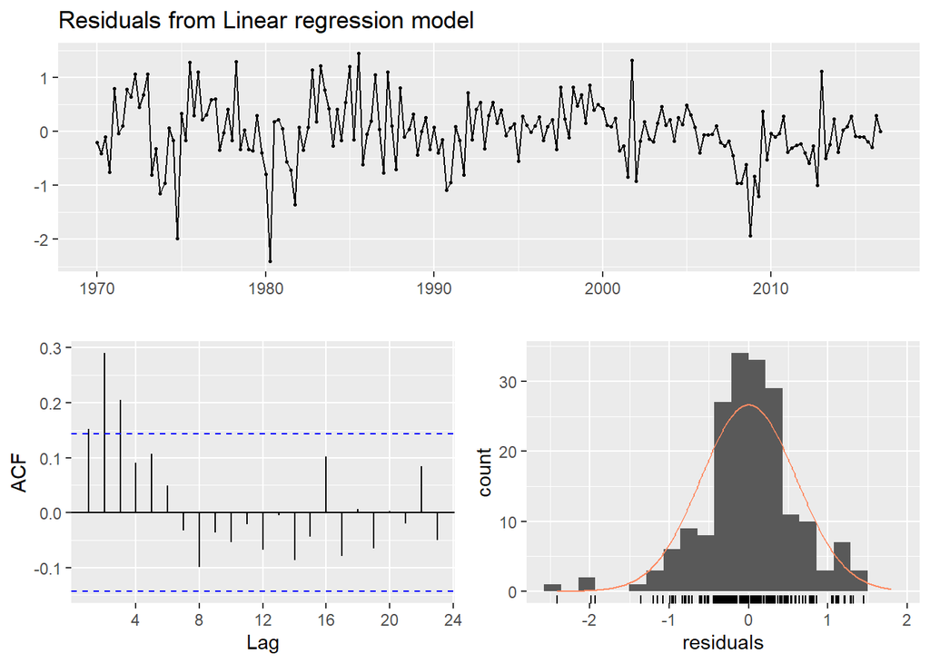

```
##
##  Breusch-Godfrey test for serial correlation of order up to 8
##
## data:  Residuals from Linear regression model
## LM test = 27.422, df = 8, p-value = 0.0005977
```

```r
checkresiduals(ts.reg1)
```

## Problems with Estimated Regression Model with Autocorrelated Errors

1. Estimated regression coefficients are not the best estimates (i.e. biased estimates).
2. Any statistical tests run on the model is incorrect.
3. AICc is no longer a good guide for model selection/performance.
4. p-values associated with coefficients are too small so predictor variables will appear to be important when they are not (i.e. spurious correlation/regression).

# Dynamic Regression Models

Dynamic regression models allows the error term to exhibit autocorrelation. We handle the autocorrelated error term by using ARIMA models.

$$Y_t = {\beta_0} + {\beta_1}{x_{1,t}} + ... +{\beta_k}{x_{k,t}} + {\eta_t}$$
where
$${\eta_t} \sim ARIMA(p,d,q)$$
For example, if ${\eta_t}$ follows an ARIMA(1,1,1) model, then the autocorrelated errors can be modeled as

$${(1 - \phi_1B)}{(1-B)}{\eta_t}={(1+\theta_1B)}{\epsilon_t}$$

## Data Preparation

In order to run a dynamic regression model, the target (dependent variable) and predictors (independent variables) need to be stationary. Thus, this leaves us with only an ARMA model to consider for the autocorrelated error term.

If we rewrite the equations above, we get

$${Y'_t}={\beta_1x'_{1,t}}+...+{\beta_kx'_{k,t}}+{\eta'_t}$$

$${(1 - \phi_1B)}{(1-B)}{\eta'_t}={(1+\theta_1B)}{\epsilon_t}$$

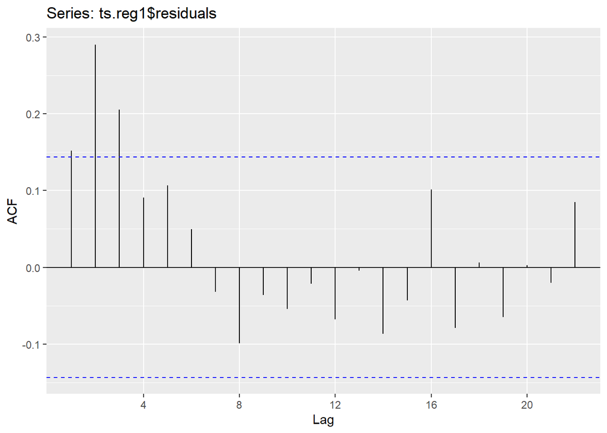

```r
ggAcf(ts.reg1$residuals)
```

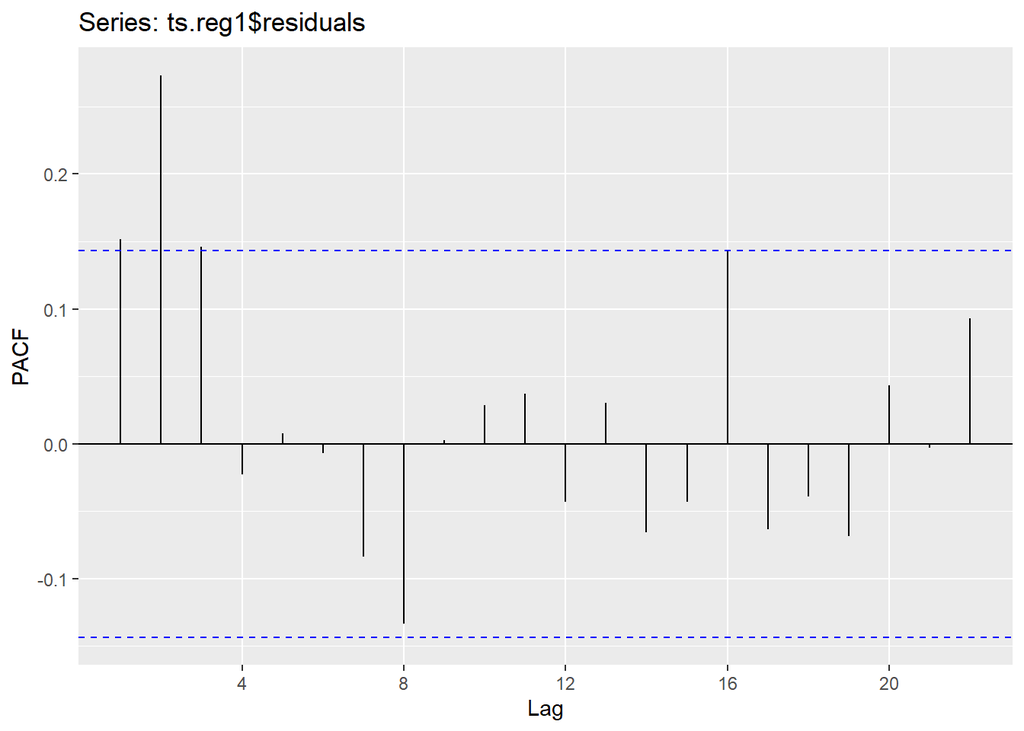

```r
ggPacf(ts.reg1$residuals)
```

```r
residuals.fit1 <- Arima(ts.reg1$residuals, order=c(1,0,0))
residuals.fit2 <- Arima(ts.reg1$residuals, order=c(2,0,0))
residuals.fit3 <- Arima(ts.reg1$residuals, order=c(3,0,0))
residuals.fit4 <- Arima(ts.reg1$residuals, order=c(4,0,0))

residuals.fit1
```

```
## Series: ts.reg1$residuals
## ARIMA(1,0,0) with non-zero mean
##
## Coefficients:
##          ar1     mean
##       0.1512  -0.0002
## s.e.  0.0721   0.0510
##
## sigma^2 estimated as 0.3547:  log likelihood=-167.45
## AIC=340.9   AICc=341.03   BIC=350.59
```

```r
residuals.fit2
```

```
## Series: ts.reg1$residuals
## ARIMA(2,0,0) with non-zero mean
##
## Coefficients:
##        ar1     ar2     mean
##       0.11  0.2718  -0.0009
## s.e.  0.07  0.0700   0.0670
##
## sigma^2 estimated as 0.3299:  log likelihood=-160.23
## AIC=328.45   AICc=328.67   BIC=341.38
```

```r
residuals.fit3
```

```
## Series: ts.reg1$residuals
## ARIMA(3,0,0) with non-zero mean
##
## Coefficients:
##          ar1     ar2     ar3     mean
##       0.0701  0.2557  0.1445  -0.0019
## s.e.  0.0720  0.0697  0.0719   0.0770
##
## sigma^2 estimated as 0.3246:  log likelihood=-158.23
## AIC=326.47   AICc=326.8   BIC=342.62
```

```r
residuals.fit4
```

```
## Series: ts.reg1$residuals
## ARIMA(4,0,0) with non-zero mean
##
## Coefficients:
##          ar1     ar2     ar3      ar4     mean
##       0.0733  0.2612  0.1460  -0.0214  -0.0016
## s.e.  0.0728  0.0722  0.0721   0.0728   0.0755
##
## sigma^2 estimated as 0.3262:  log likelihood=-158.19
## AIC=328.38   AICc=328.85   BIC=347.77
```

```r
fit.auto <- auto.arima(ts.reg1$residuals, approximation=FALSE, stepwise=FALSE)
fit.auto
```

```
## Series: ts.reg1$residuals
## ARIMA(3,0,0) with zero mean
##
## Coefficients:
##          ar1     ar2     ar3
##       0.0701  0.2557  0.1445
## s.e.  0.0720  0.0697  0.0719
##
## sigma^2 estimated as 0.3228:  log likelihood=-158.23
## AIC=324.47   AICc=324.69   BIC=337.39
```

```r
dynamic.reg.model1 <- Arima(cons_series[,1], xreg=cons_series[,2], order=c(3,0,0))

dynamic.reg.model1
```

```
## Series: cons_series[, 1]
## Regression with ARIMA(3,0,0) errors
##
## Coefficients:
##          ar1     ar2     ar3  intercept    xreg
##       0.1256  0.2377  0.1595     0.6030  0.1972
## s.e.  0.0782  0.0718  0.0724     0.0915  0.0483
##
## sigma^2 estimated as 0.3213:  log likelihood=-156.77
## AIC=325.55   AICc=326.02   BIC=344.94
```

Writing out the fitted model

$$\epsilon_{t} {\sim}N(0,0.321)$$

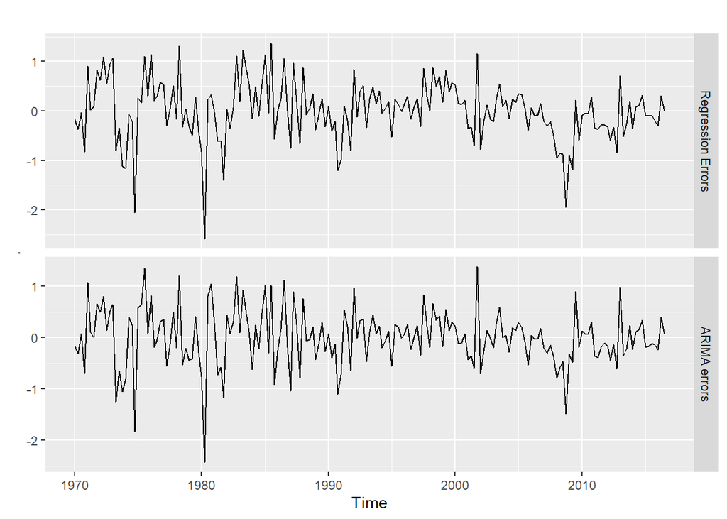

```r
cbind("Regression Errors" = residuals(dynamic.reg.model1, type="regression"),
      "ARIMA errors" = residuals(dynamic.reg.model1, type="innovation")) %>%
  autoplot(facets=TRUE)
```

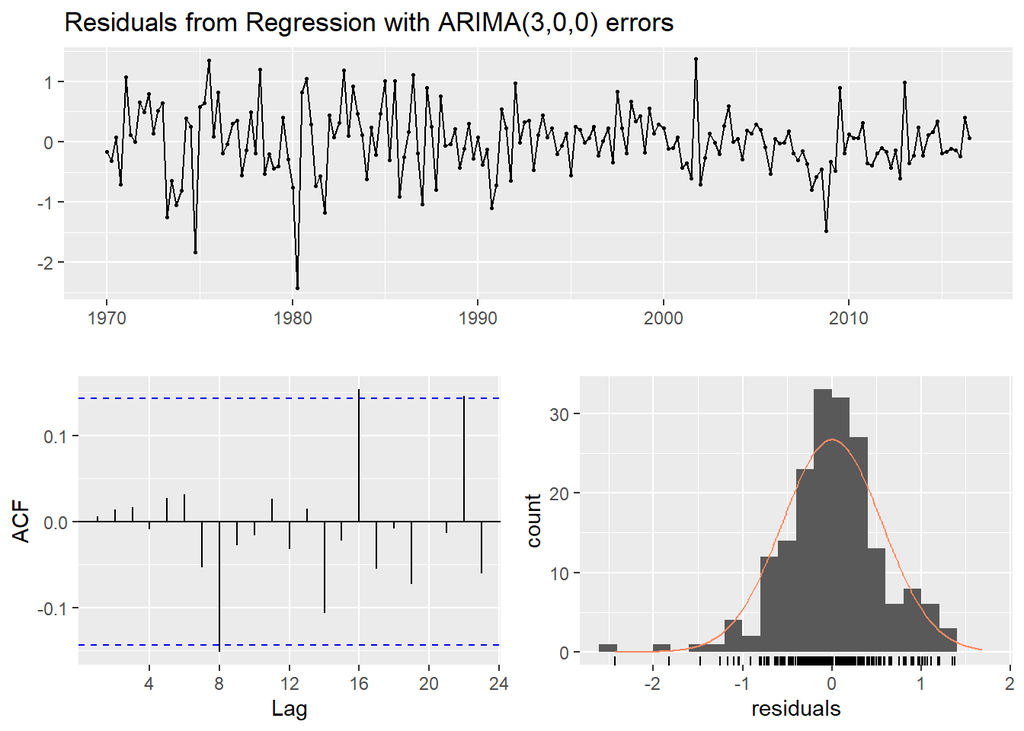

```
##
##  Ljung-Box test
##
## data:  Residuals from Regression with ARIMA(3,0,0) errors
## Q* = 5.5454, df = 3, p-value = 0.1359
##
## Model df: 5.   Total lags used: 8
```

```r
checkresiduals(dynamic.reg.model1)
```

## Using auto.arima()

```r
dynamic.reg.auto <- auto.arima(uschange[,"Consumption"],
  xreg=uschange[,"Income"], approximation = FALSE, stepwise = FALSE)
dynamic.reg.auto
```

```
## Series: uschange[, "Consumption"]
## Regression with ARIMA(3,0,0)(2,0,0)[4] errors
##
## Coefficients:
##          ar1     ar2     ar3     sar1     sar2  intercept    xreg
##       0.1238  0.2458  0.1840  -0.0120  -0.1599     0.6143  0.1836
## s.e.  0.0792  0.0728  0.0729   0.0762   0.0737     0.0838  0.0470
##
## sigma^2 estimated as 0.3165:  log likelihood=-154.45
## AIC=324.9   AICc=325.71   BIC=350.75
```

When we forecast into the future, we need to obtain forecasts for the predictors. Sometimes, these predictor forecasts are known (such as whether an intervention was applied). Sometimes, these predictor forecasts are unknown. In these latter cases, we have to use our best judgments.

We will calculate forecasts for the next eight quarters assuming that the future percentage changes in personal disposable income will be equal to the mean percentage change from the last forty years.

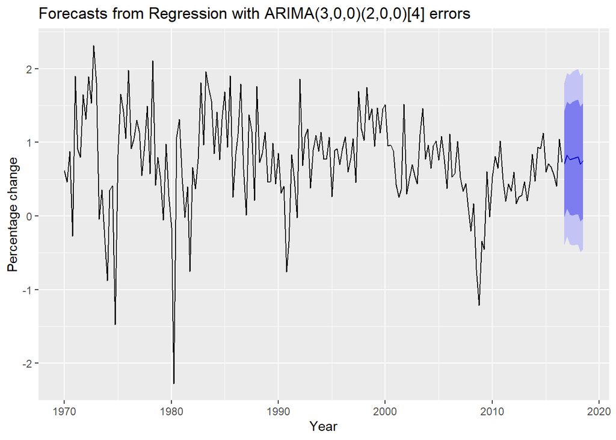

```r
mean.income.change <- mean(uschange[,2])
expected.income.change <- rep(mean.income.change,8)#repeats 8 times
fcast <- forecast(dynamic.reg.auto, xreg=expected.income.change, 8)
autoplot(fcast) + xlab("Year") +
  ylab("Percentage change")
```

# Daily Electricity Demand Example

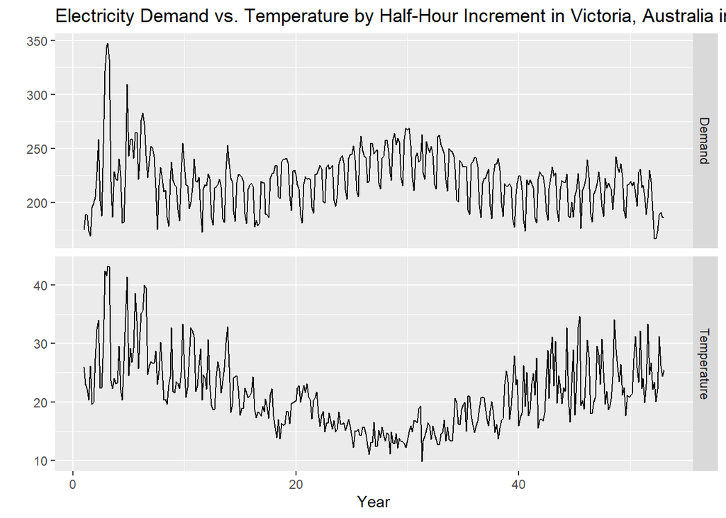

```r
autoplot(elecdaily[,c(1,3)], facets=TRUE) +
  xlab("Year") + ylab("") +
  ggtitle("Electricity Demand vs. Temperature by Half-Hour Increment in Victoria, Australia in 2014")
```

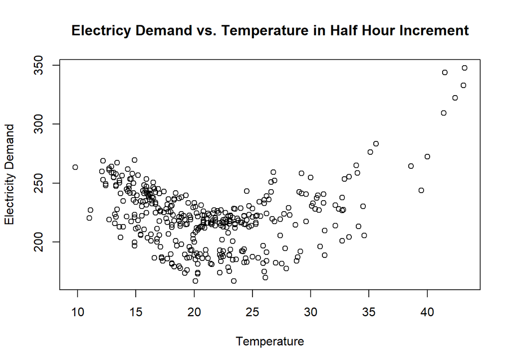

```r
plot(elecdaily[,3], elecdaily[,1],
     main = "Electricy Demand vs. Temperature in Half Hour Increment", xlab = "Temperature", ylab = "Electricity Demand")
```

Can you fit a linear regression model where Demand is the target and WorkDay and Temperature are the predictors?

```r
fit <- tslm(Demand~Temperature + WorkDay, data=elecdaily)
summary(fit)
```

```
##
## Call:
## tslm(formula = Demand ~ Temperature + WorkDay, data = elecdaily)
##
## Residuals:
##     Min      1Q  Median      3Q     Max
## -47.977 -13.915  -5.377  11.762 104.870
##
## Coefficients:
##             Estimate Std. Error t value Pr(>|t|)
## (Intercept) 186.8286     4.2901  43.549  < 2e-16 ***
## Temperature   0.4757     0.1780   2.673  0.00786 **
## WorkDay      35.3871     2.3582  15.006  < 2e-16 ***
## ---
## Signif. codes:  0 '***' 0.001 '**' 0.01 '*' 0.05 '.' 0.1 ' ' 1
##
## Residual standard error: 20.87 on 362 degrees of freedom
## Multiple R-squared:  0.3892, Adjusted R-squared:  0.3859
## F-statistic: 115.4 on 2 and 362 DF,  p-value: < 2.2e-16
```

```r
Temperature_squared <- elecdaily[,3]^2
fit.quadratic <- tslm(Demand~Temperature + Temperature_squared + WorkDay, data=elecdaily)
summary(fit.quadratic)
```

```
##
## Call:
## tslm(formula = Demand ~ Temperature + Temperature_squared + WorkDay,
##     data = elecdaily)
##
## Residuals:
##     Min      1Q  Median      3Q     Max
## -33.379  -5.932  -0.248   6.295  47.638
##
## Coefficients:
##                      Estimate Std. Error t value Pr(>|t|)
## (Intercept)         361.54457    5.98812   60.38   <2e-16 ***
## Temperature         -15.16262    0.50615  -29.96   <2e-16 ***
## Temperature_squared   0.32239    0.01026   31.42   <2e-16 ***
## WorkDay              35.21590    1.22189   28.82   <2e-16 ***
## ---
## Signif. codes:  0 '***' 0.001 '**' 0.01 '*' 0.05 '.' 0.1 ' ' 1
##
## Residual standard error: 10.82 on 361 degrees of freedom
## Multiple R-squared:  0.8365, Adjusted R-squared:  0.8351
## F-statistic: 615.6 on 3 and 361 DF,  p-value: < 2.2e-16
```

Check the residuals and determine whether autocorrelation exists

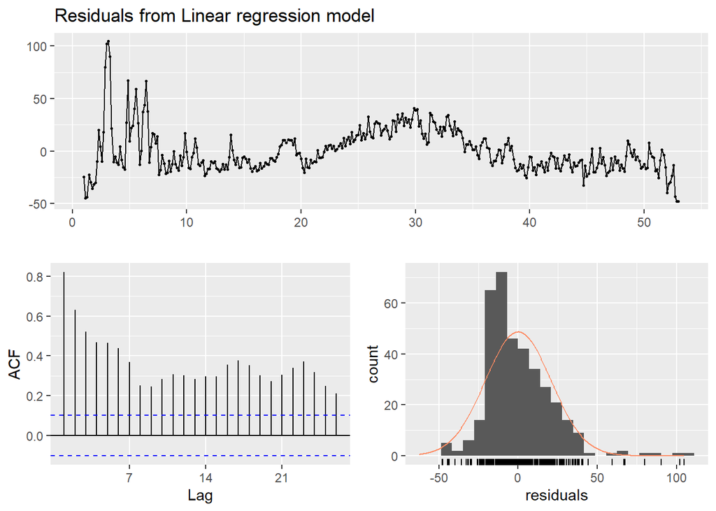

```
##
##  Breusch-Godfrey test for serial correlation of order up to 14
##
## data:  Residuals from Linear regression model
## LM test = 273.94, df = 14, p-value < 2.2e-16
```

```r
checkresiduals(fit)
```

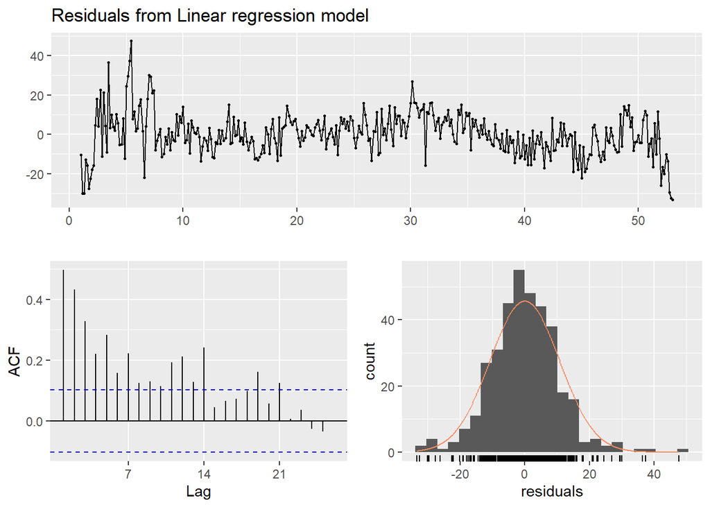

```
##
##  Breusch-Godfrey test for serial correlation of order up to 14
##
## data:  Residuals from Linear regression model
## LM test = 147.92, df = 14, p-value < 2.2e-16
```

```r
checkresiduals(fit.quadratic)
```

Fit a dynamic regression model if needed to account for autocorrelated residuals

```r
predictors <- cbind(MaxTemp = elecdaily[, "Temperature"],
              MaxTempSq = elecdaily[, "Temperature"]^2,
              Workday = elecdaily[, "WorkDay"])
fit.auto <- auto.arima(elecdaily[,1], xreg=predictors,
                       approximation=FALSE, stepwise=FALSE)
fit.auto
```

```
## Series: elecdaily[, 1]
## Regression with ARIMA(1,1,1)(2,0,0)[7] errors
##
## Coefficients:
##          ar1      ma1    sar1    sar2  MaxTemp  MaxTempSq  Workday
##       0.8071  -0.9812  0.2179  0.4002  -7.9499     0.1864  30.4099
## s.e.  0.0438   0.0194  0.0510  0.0554   0.4052     0.0078   1.2981
##
## sigma^2 estimated as 44.59:  log likelihood=-1205.83
## AIC=2427.65   AICc=2428.06   BIC=2458.83
```

Using the estimated model above, please forecast 14 days ahead starting from Thursday 1 January 2015 (a non-work-day being a public holiday for New Years Day). But for the sake of illustration, we will use scenario based forecasting where we set the temperature for the next 14 days to a constant 26 degrees. Revise the code chunk below to run your forecasts.

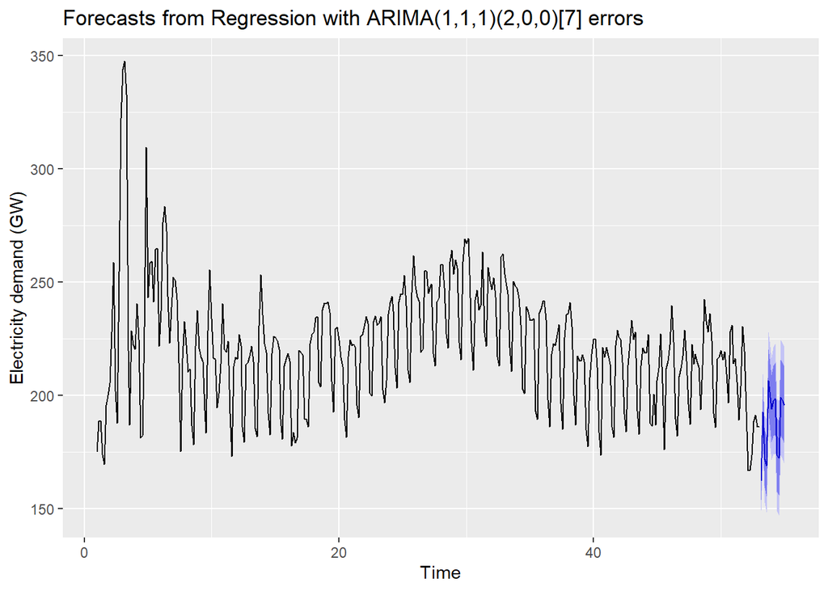

```r
fcast <- forecast(fit.auto,
  xreg = cbind(MaxTemp=rep(26,14), MaxTempSq=rep(26^2,14),
    Workday=c(0,1,0,0,1,1,1,1,1,0,0,1,1,1)))
autoplot(fcast) + ylab("Electricity demand (GW)")
```

# Stochastic and Deterministic Trends

When we have a linear trend in a dynamic regression model, we can model it in two ways:

## 1. Deterministic

$$Y_t = \beta_0 + \beta_{1}t + \eta_t$$
where $\eta_t$ follows an ARMA process.

## 2. Stochastic

$$Y_t = \beta_0 + \beta_{1}t + \eta_t$$
where $\eta_t$ follows an ARIMA process with d=1. We can take the first-order difference so that the error term follows an ARMA process:

$$Y'_t = \beta_{1} + \eta'_t$$
$$Y_t = Y_{t-1} + \beta_{1} + \eta'_t$$
Even though they are similar, the forecasts for each type of trend are quite different.

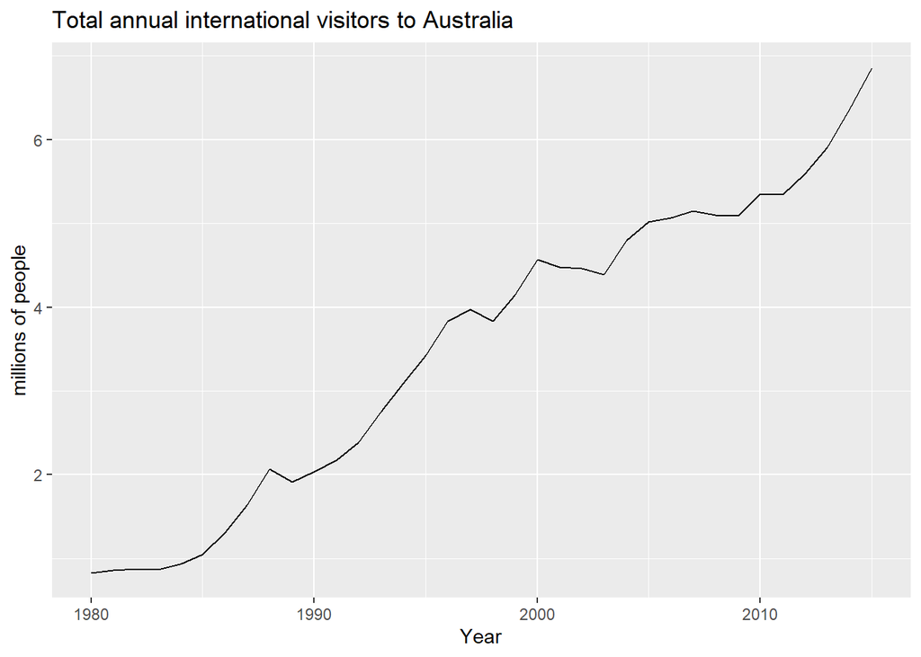

```r
autoplot(austa) + xlab("Year") +
  ylab("millions of people") +
  ggtitle("Total annual international visitors to Australia")
```

Deterministic trend

```r
trend <- seq_along(austa)
fit1 <- auto.arima(austa, d=0, xreg=trend)
fit1
```

```
## Series: austa
## Regression with ARIMA(2,0,0) errors
##
## Coefficients:
##          ar1      ar2  intercept    xreg
##       1.1127  -0.3805     0.4156  0.1710
## s.e.  0.1600   0.1585     0.1897  0.0088
##
## sigma^2 estimated as 0.02979:  log likelihood=13.6
## AIC=-17.2   AICc=-15.2   BIC=-9.28
```

This model can be written as
$$Y_t = 0.416 + 0.171t + \eta_t$$

Stochastic trend

```r
fit2 <- auto.arima(austa, d=1)
fit2
```

```
## Series: austa
## ARIMA(0,1,1) with drift
##
## Coefficients:
##          ma1   drift
##       0.3006  0.1735
## s.e.  0.1647  0.0390
##
## sigma^2 estimated as 0.03376:  log likelihood=10.62
## AIC=-15.24   AICc=-14.46   BIC=-10.57
```

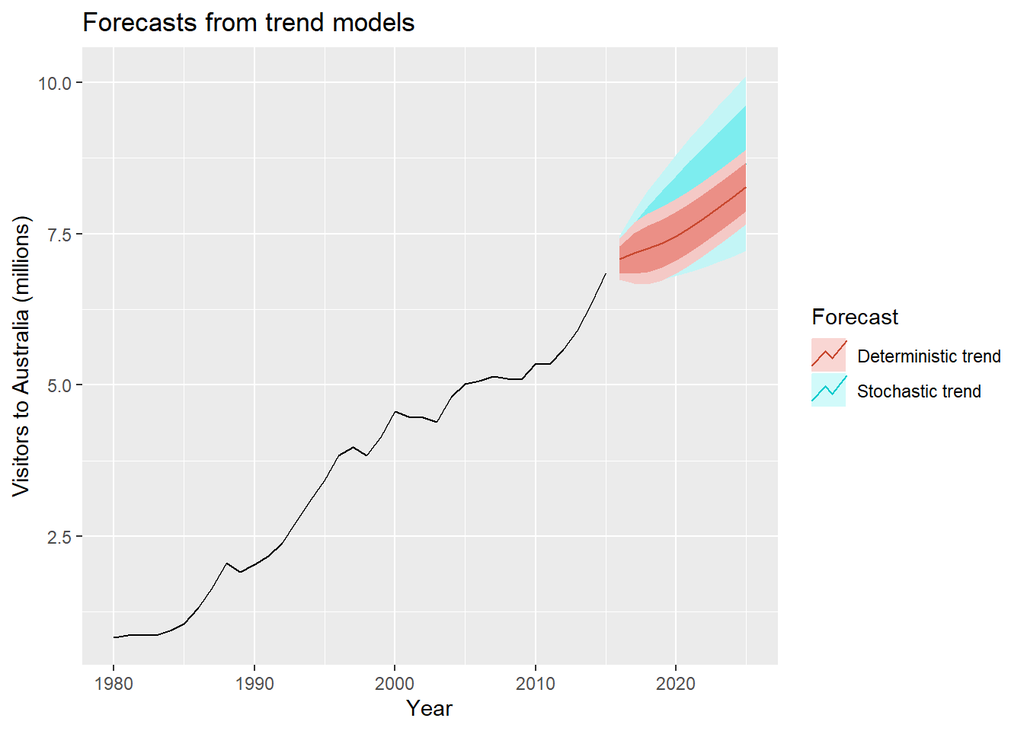

```r
fc1 <- forecast(fit1,
  xreg = length(austa) + 1:10)
fc2 <- forecast(fit2, h=10)
autoplot(austa) +
  autolayer(fc2, series="Stochastic trend") +
  autolayer(fc1, series="Deterministic trend") +
  ggtitle("Forecasts from trend models") +
  xlab("Year") + ylab("Visitors to Australia (millions)") +
  guides(colour=guide_legend(title="Forecast"))
```

From Hyndman (2019, Section 9.4):

There is an implicit assumption with deterministic trends that the slope of the trend is not going to change over time. On the other hand, stochastic trends can change, and the estimated growth is only assumed to be the average growth over the historical period, not necessarily the rate of growth that will be observed into the future. Consequently, it is safer to forecast with stochastic trends, especially for longer forecast horizons, as the prediction intervals allow for greater uncertainty in future growth (Hyndman 2019, https://otexts.com/fpp2/stochastic-and-deterministic-trends.html).

# Dynamic Harmonic Regression

Remember we learned last week that the maximum number of sine and cosine terms to include in a harmonic regression is equivalent to 1/2 the number of periods in a season.

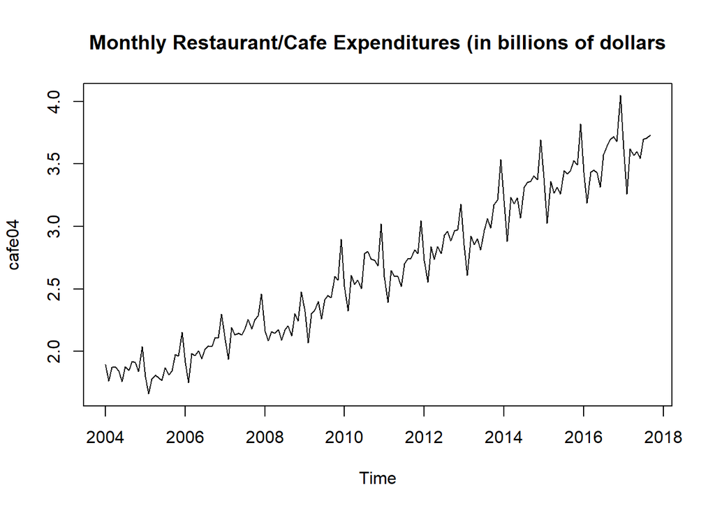

```r
cafe04 <- window(auscafe, start=2004)

plot(cafe04, main = "Monthly Restaurant/Cafe Expenditures (in billions of dollars")
```

The variance seem to be changing. We should consider transforming the series to stabilize the variance.

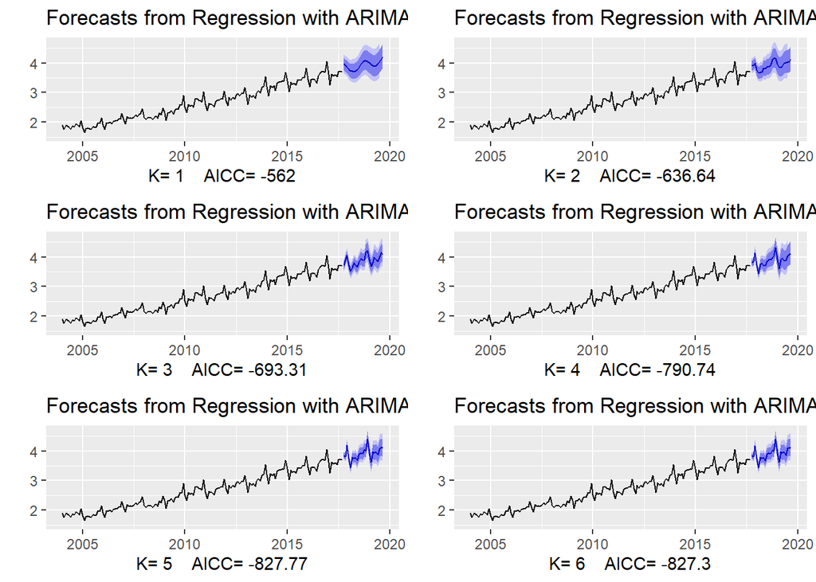

```r
plots <- list()
for (i in seq(6)) {
  fit <- auto.arima(cafe04, xreg = fourier(cafe04, K = i),
    seasonal = FALSE, lambda = 0)
  plots[[i]] <- autoplot(forecast(fit,
      xreg=fourier(cafe04, K=i, h=24))) +
    xlab(paste("K=",i,"   AICC=",round(fit[["aicc"]],2))) +
    ylab("") + ylim(1.5,4.7)
}
gridExtra::grid.arrange(
  plots[[1]],plots[[2]],plots[[3]],
  plots[[4]],plots[[5]],plots[[6]], nrow=3)
```

The model with the lowest AICc is the fifth dynamic harmonic regression model with five pairs of sine and cosine terms and errors with ARIMA(0,1,1).

```r
fit <- auto.arima(cafe04, xreg = fourier(cafe04, K = 5),
    seasonal = FALSE, lambda = 0)

fit
```

```
## Series: cafe04
## Regression with ARIMA(0,1,1) errors
## Box Cox transformation: lambda= 0
##
## Coefficients:
##           ma1   drift    S1-12   C1-12    S2-12   C2-12    S3-12   C3-12
##       -0.4027  0.0041  -0.0273  0.0240  -0.0146  0.0167  -0.0066  0.0353
## s.e.   0.0634  0.0008   0.0026  0.0026   0.0017  0.0017   0.0015  0.0015
##        S4-12   C4-12   S5-12   C5-12
##       0.0132  0.0156  0.0182  0.0187
## s.e.  0.0014  0.0014  0.0014  0.0014
##
## sigma^2 estimated as 0.000341:  log likelihood=428.1
## AIC=-830.19   AICc=-827.77   BIC=-789.89
```

# Lagged Predictors

The impact of a predictor may be spread out over multiple periods.

$$Y_t = \beta_0 + \gamma_0x_t + \gamma_1x_{t-1} + \gamma_2x_{t-2} + ... + \gamma_kx_{t-k} + \eta_t$$
where $\eta_t$ follows an ARIMA process.

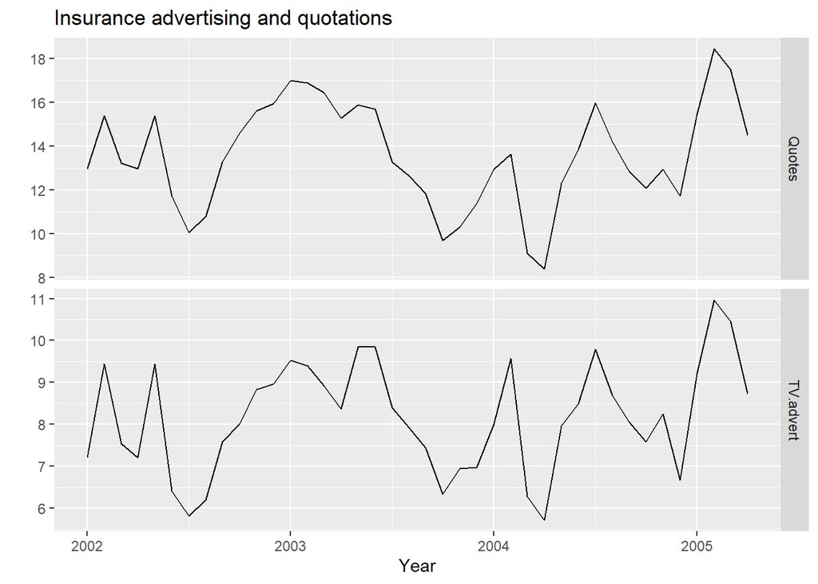

```r
autoplot(insurance, facets=TRUE) +
  xlab("Year") + ylab("") +
  ggtitle("Insurance advertising and quotations")
```

```r
# Lagged predictors. Test 0, 1, 2 or 3 lags.
Advert <- cbind(
    AdLag0 = insurance[,"TV.advert"],
    AdLag1 = stats::lag(insurance[,"TV.advert"],-1),
    AdLag2 = stats::lag(insurance[,"TV.advert"],-2),
    AdLag3 = stats::lag(insurance[,"TV.advert"],-3)) %>%
  head(NROW(insurance))

# Restrict data so models use same fitting period
# Starting with April 2002 through April 2005
fit1 <- auto.arima(insurance[4:40,1], xreg=Advert[4:40,1],
  stationary=TRUE)
fit2 <- auto.arima(insurance[4:40,1], xreg=Advert[4:40,1:2],
  stationary=TRUE)
fit3 <- auto.arima(insurance[4:40,1], xreg=Advert[4:40,1:3],
  stationary=TRUE)
fit4 <- auto.arima(insurance[4:40,1], xreg=Advert[4:40,1:4],
  stationary=TRUE)

c(fit1[["aicc"]],fit2[["aicc"]],fit3[["aicc"]],fit4[["aicc"]])
```

```
## [1] 68.49968 60.02357 62.83253 65.45747
```

Re-estimate the model with two lagged predictors.

```r
(fit <- auto.arima(insurance[,1], xreg=Advert[,1:2],
  stationary=TRUE))
```

```
## Series: insurance[, 1]
## Regression with ARIMA(3,0,0) errors
##
## Coefficients:
##          ar1      ar2     ar3  intercept  AdLag0  AdLag1
##       1.4117  -0.9317  0.3591     2.0393  1.2564  0.1625
## s.e.  0.1698   0.2545  0.1592     0.9931  0.0667  0.0591
##
## sigma^2 estimated as 0.2165:  log likelihood=-23.89
## AIC=61.78   AICc=65.4   BIC=73.43
```

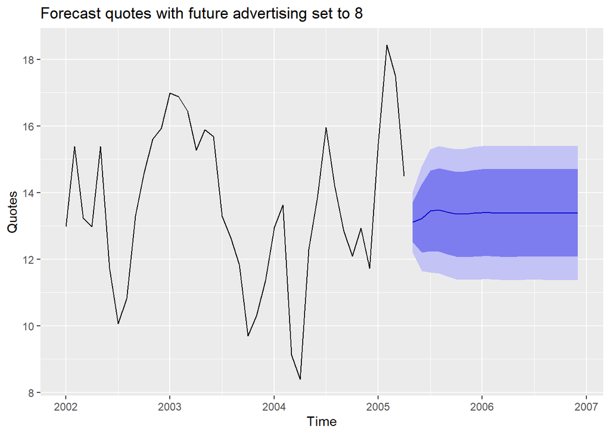

```r
fc8 <- forecast(fit, h=20,
  xreg=cbind(AdLag0 = rep(8,20),
             AdLag1 = c(Advert[40,1], rep(8,19))))
autoplot(fc8) + ylab("Quotes") +
  ggtitle("Forecast quotes with future advertising set to 8")
```